# Bellabeat Case Study

Łukasz Janiak

08-04-2022

## Business Task

Questions for analysis:

- What are some trends in smart device usage?
- How could these trends apply to Bellabeat customers?

The purpose of this analysis is to find trends in Fitbit tracking device usage and use these insights to set Bellabeat development in the right direction.

## Data source

Data was downloaded from [Fitbit Fitness Tracker Data](https://www.kaggle.com/datasets/arashnic/fitbit) from the Kaggle web repository.  
License: CC0: Public Domain

## Data limitations

- Small sample size - only 33 unique users took part in this survey
- “Seasonal” data - data contains only records from one month preiod (may not be representative of the entire year)
- No metadata - the data does not contain any demographic information, so it may come from a specific group and not represent the general population

## Loading packages

```r
library("readr")
library("ggplot2")
library("dplyr")
library("lubridate")
library("tidyr")
library("janitor")
library("stringr")
```

## Importing datasets

```r
daily_activity <- read_csv("Fitabase_Data_4.12.16-5.12.16/dailyActivity_merged.csv") # nolint
hourly_calories <- read_csv("Fitabase_Data_4.12.16-5.12.16/hourlyCalories_merged.csv" ) # nolint
hourly_intensities <- read_csv("Fitabase_Data_4.12.16-5.12.16/hourlyIntensities_merged.csv") # nolint
hourly_steps <- read_csv("Fitabase_Data_4.12.16-5.12.16/hourlySteps_merged.csv")
sleep_day <- read_csv("Fitabase_Data_4.12.16-5.12.16/sleepDay_merged.csv")
heart_rate <- read_csv("Fitabase_Data_4.12.16-5.12.16/heartrate_seconds_merged.csv") # nolint
weight_log <- read_csv("Fitabase_Data_4.12.16-5.12.16/weightLogInfo_merged.csv")
```

## Data Preview

### Daily Activity

```r
head(daily_activity)
```

```
## # A tibble: 6 x 15
##        Id ActivityDate TotalSteps TotalDistance TrackerDistance LoggedActivitie~
##     <dbl> <chr>             <dbl>         <dbl>           <dbl>            <dbl>
## 1  1.50e9 4/12/2016         13162          8.5             8.5                 0
## 2  1.50e9 4/13/2016         10735          6.97            6.97                0
## 3  1.50e9 4/14/2016         10460          6.74            6.74                0
## 4  1.50e9 4/15/2016          9762          6.28            6.28                0
## 5  1.50e9 4/16/2016         12669          8.16            8.16                0
## 6  1.50e9 4/17/2016          9705          6.48            6.48                0
## # ... with 9 more variables: VeryActiveDistance <dbl>,
## #   ModeratelyActiveDistance <dbl>, LightActiveDistance <dbl>,
## #   SedentaryActiveDistance <dbl>, VeryActiveMinutes <dbl>,
## #   FairlyActiveMinutes <dbl>, LightlyActiveMinutes <dbl>,
## #   SedentaryMinutes <dbl>, Calories <dbl>
```

```r
str(daily_activity)
```

```
## spec_tbl_df [940 x 15] (S3: spec_tbl_df/tbl_df/tbl/data.frame)
##  $ Id                      : num [1:940] 1.5e+09 1.5e+09 1.5e+09 1.5e+09 1.5e+09 ...
##  $ ActivityDate            : chr [1:940] "4/12/2016" "4/13/2016" "4/14/2016" "4/15/2016" ...
##  $ TotalSteps              : num [1:940] 13162 10735 10460 9762 12669 ...
##  $ TotalDistance           : num [1:940] 8.5 6.97 6.74 6.28 8.16 ...
##  $ TrackerDistance         : num [1:940] 8.5 6.97 6.74 6.28 8.16 ...
##  $ LoggedActivitiesDistance: num [1:940] 0 0 0 0 0 0 0 0 0 0 ...
##  $ VeryActiveDistance      : num [1:940] 1.88 1.57 2.44 2.14 2.71 ...
##  $ ModeratelyActiveDistance: num [1:940] 0.55 0.69 0.4 1.26 0.41 ...
##  $ LightActiveDistance     : num [1:940] 6.06 4.71 3.91 2.83 5.04 ...
##  $ SedentaryActiveDistance : num [1:940] 0 0 0 0 0 0 0 0 0 0 ...
##  $ VeryActiveMinutes       : num [1:940] 25 21 30 29 36 38 42 50 28 19 ...
##  $ FairlyActiveMinutes     : num [1:940] 13 19 11 34 10 20 16 31 12 8 ...
##  $ LightlyActiveMinutes    : num [1:940] 328 217 181 209 221 164 233 264 205 211 ...
##  $ SedentaryMinutes        : num [1:940] 728 776 1218 726 773 ...
##  $ Calories                : num [1:940] 1985 1797 1776 1745 1863 ...
##  - attr(*, "spec")=
##   .. cols(
##   ..   Id = col_double(),
##   ..   ActivityDate = col_character(),
##   ..   TotalSteps = col_double(),
##   ..   TotalDistance = col_double(),
##   ..   TrackerDistance = col_double(),
##   ..   LoggedActivitiesDistance = col_double(),
##   ..   VeryActiveDistance = col_double(),
##   ..   ModeratelyActiveDistance = col_double(),
##   ..   LightActiveDistance = col_double(),
##   ..   SedentaryActiveDistance = col_double(),
##   ..   VeryActiveMinutes = col_double(),
##   ..   FairlyActiveMinutes = col_double(),
##   ..   LightlyActiveMinutes = col_double(),
##   ..   SedentaryMinutes = col_double(),
##   ..   Calories = col_double()
##   .. )
##  - attr(*, "problems")=<externalptr>
```

### Hourly Calories

```r
head(hourly_calories)
```

```
## # A tibble: 6 x 3
##           Id ActivityHour          Calories
##        <dbl> <chr>                    <dbl>
## 1 1503960366 4/12/2016 12:00:00 AM       81
## 2 1503960366 4/12/2016 1:00:00 AM        61
## 3 1503960366 4/12/2016 2:00:00 AM        59
## 4 1503960366 4/12/2016 3:00:00 AM        47
## 5 1503960366 4/12/2016 4:00:00 AM        48
## 6 1503960366 4/12/2016 5:00:00 AM        48
```

```r
str(hourly_calories)
```

```
## spec_tbl_df [22,099 x 3] (S3: spec_tbl_df/tbl_df/tbl/data.frame)
##  $ Id          : num [1:22099] 1.5e+09 1.5e+09 1.5e+09 1.5e+09 1.5e+09 ...
##  $ ActivityHour: chr [1:22099] "4/12/2016 12:00:00 AM" "4/12/2016 1:00:00 AM" "4/12/2016 2:00:00 AM" "4/12/2016 3:00:00 AM" ...
##  $ Calories    : num [1:22099] 81 61 59 47 48 48 48 47 68 141 ...
##  - attr(*, "spec")=
##   .. cols(
##   ..   Id = col_double(),
##   ..   ActivityHour = col_character(),
##   ..   Calories = col_double()
##   .. )
##  - attr(*, "problems")=<externalptr>
```

### Hourly Intensities

```r
head(hourly_intensities)
```

```
## # A tibble: 6 x 4
##           Id ActivityHour          TotalIntensity AverageIntensity
##        <dbl> <chr>                          <dbl>            <dbl>
## 1 1503960366 4/12/2016 12:00:00 AM             20            0.333
## 2 1503960366 4/12/2016 1:00:00 AM               8            0.133
## 3 1503960366 4/12/2016 2:00:00 AM               7            0.117
## 4 1503960366 4/12/2016 3:00:00 AM               0            0
## 5 1503960366 4/12/2016 4:00:00 AM               0            0
## 6 1503960366 4/12/2016 5:00:00 AM               0            0
```

```r
str(hourly_intensities)
```

```
## spec_tbl_df [22,099 x 4] (S3: spec_tbl_df/tbl_df/tbl/data.frame)
##  $ Id              : num [1:22099] 1.5e+09 1.5e+09 1.5e+09 1.5e+09 1.5e+09 ...
##  $ ActivityHour    : chr [1:22099] "4/12/2016 12:00:00 AM" "4/12/2016 1:00:00 AM" "4/12/2016 2:00:00 AM" "4/12/2016 3:00:00 AM" ...
##  $ TotalIntensity  : num [1:22099] 20 8 7 0 0 0 0 0 13 30 ...
##  $ AverageIntensity: num [1:22099] 0.333 0.133 0.117 0 0 ...
##  - attr(*, "spec")=
##   .. cols(
##   ..   Id = col_double(),
##   ..   ActivityHour = col_character(),
##   ..   TotalIntensity = col_double(),
##   ..   AverageIntensity = col_double()
##   .. )
##  - attr(*, "problems")=<externalptr>
```

### Hourly Steps

```r
head(hourly_steps)
```

```
## # A tibble: 6 x 3
##           Id ActivityHour          StepTotal
##        <dbl> <chr>                     <dbl>
## 1 1503960366 4/12/2016 12:00:00 AM       373
## 2 1503960366 4/12/2016 1:00:00 AM        160
## 3 1503960366 4/12/2016 2:00:00 AM        151
## 4 1503960366 4/12/2016 3:00:00 AM          0
## 5 1503960366 4/12/2016 4:00:00 AM          0
## 6 1503960366 4/12/2016 5:00:00 AM          0
```

```r
str(hourly_steps)
```

```
## spec_tbl_df [22,099 x 3] (S3: spec_tbl_df/tbl_df/tbl/data.frame)
##  $ Id          : num [1:22099] 1.5e+09 1.5e+09 1.5e+09 1.5e+09 1.5e+09 ...
##  $ ActivityHour: chr [1:22099] "4/12/2016 12:00:00 AM" "4/12/2016 1:00:00 AM" "4/12/2016 2:00:00 AM" "4/12/2016 3:00:00 AM" ...
##  $ StepTotal   : num [1:22099] 373 160 151 0 0 ...
##  - attr(*, "spec")=
##   .. cols(
##   ..   Id = col_double(),
##   ..   ActivityHour = col_character(),
##   ..   StepTotal = col_double()
##   .. )
##  - attr(*, "problems")=<externalptr>
```

### Sleep Day

```r
head(sleep_day)
```

```
## # A tibble: 6 x 5
##           Id SleepDay           TotalSleepRecor~ TotalMinutesAsl~ TotalTimeInBed
##        <dbl> <chr>                         <dbl>            <dbl>          <dbl>
## 1 1503960366 4/12/2016 12:00:0~                1              327            346
## 2 1503960366 4/13/2016 12:00:0~                2              384            407
## 3 1503960366 4/15/2016 12:00:0~                1              412            442
## 4 1503960366 4/16/2016 12:00:0~                2              340            367
## 5 1503960366 4/17/2016 12:00:0~                1              700            712
## 6 1503960366 4/19/2016 12:00:0~                1              304            320
```

```r
str(sleep_day)
```

```
## spec_tbl_df [413 x 5] (S3: spec_tbl_df/tbl_df/tbl/data.frame)
##  $ Id                : num [1:413] 1.5e+09 1.5e+09 1.5e+09 1.5e+09 1.5e+09 ...
##  $ SleepDay          : chr [1:413] "4/12/2016 12:00:00 AM" "4/13/2016 12:00:00 AM" "4/15/2016 12:00:00 AM" "4/16/2016 12:00:00 AM" ...
##  $ TotalSleepRecords : num [1:413] 1 2 1 2 1 1 1 1 1 1 ...
##  $ TotalMinutesAsleep: num [1:413] 327 384 412 340 700 304 360 325 361 430 ...
##  $ TotalTimeInBed    : num [1:413] 346 407 442 367 712 320 377 364 384 449 ...
##  - attr(*, "spec")=
##   .. cols(
##   ..   Id = col_double(),
##   ..   SleepDay = col_character(),
##   ..   TotalSleepRecords = col_double(),
##   ..   TotalMinutesAsleep = col_double(),
##   ..   TotalTimeInBed = col_double()
##   .. )
##  - attr(*, "problems")=<externalptr>
```

### Heart Rate

```r
head(heart_rate)
```

```
## # A tibble: 6 x 3
##           Id Time                 Value
##        <dbl> <chr>                <dbl>
## 1 2022484408 4/12/2016 7:21:00 AM    97
## 2 2022484408 4/12/2016 7:21:05 AM   102
## 3 2022484408 4/12/2016 7:21:10 AM   105
## 4 2022484408 4/12/2016 7:21:20 AM   103
## 5 2022484408 4/12/2016 7:21:25 AM   101
## 6 2022484408 4/12/2016 7:22:05 AM    95
```

```r
str(heart_rate)
```

```
## spec_tbl_df [2,483,658 x 3] (S3: spec_tbl_df/tbl_df/tbl/data.frame)
##  $ Id   : num [1:2483658] 2.02e+09 2.02e+09 2.02e+09 2.02e+09 2.02e+09 ...
##  $ Time : chr [1:2483658] "4/12/2016 7:21:00 AM" "4/12/2016 7:21:05 AM" "4/12/2016 7:21:10 AM" "4/12/2016 7:21:20 AM" ...
##  $ Value: num [1:2483658] 97 102 105 103 101 95 91 93 94 93 ...
##  - attr(*, "spec")=
##   .. cols(
##   ..   Id = col_double(),
##   ..   Time = col_character(),
##   ..   Value = col_double()
##   .. )
##  - attr(*, "problems")=<externalptr>
```

### Weight Log

```r
head(weight_log)
```

```
## # A tibble: 6 x 8
##           Id Date       WeightKg WeightPounds   Fat   BMI IsManualReport   LogId
##        <dbl> <chr>         <dbl>        <dbl> <dbl> <dbl> <lgl>            <dbl>
## 1 1503960366 5/2/2016 ~     52.6         116.    22  22.6 TRUE           1.46e12
## 2 1503960366 5/3/2016 ~     52.6         116.    NA  22.6 TRUE           1.46e12
## 3 1927972279 4/13/2016~    134.          294.    NA  47.5 FALSE          1.46e12
## 4 2873212765 4/21/2016~     56.7         125.    NA  21.5 TRUE           1.46e12
## 5 2873212765 5/12/2016~     57.3         126.    NA  21.7 TRUE           1.46e12
## 6 4319703577 4/17/2016~     72.4         160.    25  27.5 TRUE           1.46e12
```

```r
str(weight_log)
```

```
## spec_tbl_df [67 x 8] (S3: spec_tbl_df/tbl_df/tbl/data.frame)
##  $ Id            : num [1:67] 1.50e+09 1.50e+09 1.93e+09 2.87e+09 2.87e+09 ...
##  $ Date          : chr [1:67] "5/2/2016 11:59:59 PM" "5/3/2016 11:59:59 PM" "4/13/2016 1:08:52 AM" "4/21/2016 11:59:59 PM" ...
##  $ WeightKg      : num [1:67] 52.6 52.6 133.5 56.7 57.3 ...
##  $ WeightPounds  : num [1:67] 116 116 294 125 126 ...
##  $ Fat           : num [1:67] 22 NA NA NA NA 25 NA NA NA NA ...
##  $ BMI           : num [1:67] 22.6 22.6 47.5 21.5 21.7 ...
##  $ IsManualReport: logi [1:67] TRUE TRUE FALSE TRUE TRUE TRUE ...
##  $ LogId         : num [1:67] 1.46e+12 1.46e+12 1.46e+12 1.46e+12 1.46e+12 ...
##  - attr(*, "spec")=
##   .. cols(
##   ..   Id = col_double(),
##   ..   Date = col_character(),
##   ..   WeightKg = col_double(),
##   ..   WeightPounds = col_double(),
##   ..   Fat = col_double(),
##   ..   BMI = col_double(),
##   ..   IsManualReport = col_logical(),
##   ..   LogId = col_double()
##   .. )
##  - attr(*, "problems")=<externalptr>
```

## Data cleaning

First, I’m going to check for any duplicates and remove if any occurs. Then I’m going to split timestamps into two separate columns (date and time).

### Daily Activity

```r
sum(duplicated(daily_activity))
```

```
## [1] 0
```

```r
daily_activity <- daily_activity %>%
  clean_names() %>%
  mutate(activity_date = mdy(activity_date), day_of_week = weekdays(activity_date)) %>% # nolint
  rename("date" = activity_date)

head(daily_activity)
```

```
## # A tibble: 6 x 16
##       id date       total_steps total_distance tracker_distance logged_activiti~
##    <dbl> <date>           <dbl>          <dbl>            <dbl>            <dbl>
## 1 1.50e9 2016-04-12       13162           8.5              8.5                 0
## 2 1.50e9 2016-04-13       10735           6.97             6.97                0
## 3 1.50e9 2016-04-14       10460           6.74             6.74                0
## 4 1.50e9 2016-04-15        9762           6.28             6.28                0
## 5 1.50e9 2016-04-16       12669           8.16             8.16                0
## 6 1.50e9 2016-04-17        9705           6.48             6.48                0
## # ... with 10 more variables: very_active_distance <dbl>,
## #   moderately_active_distance <dbl>, light_active_distance <dbl>,
## #   sedentary_active_distance <dbl>, very_active_minutes <dbl>,
## #   fairly_active_minutes <dbl>, lightly_active_minutes <dbl>,
## #   sedentary_minutes <dbl>, calories <dbl>, day_of_week <chr>
```

### Hourly Calories

```r
sum(duplicated(hourly_calories))
```

```
## [1] 0
```

```r
hourly_calories <- hourly_calories %>%
  clean_names() %>%
  separate(col = activity_hour, into = c("date", "time", "indicator"), sep = " ") %>% # nolint
  mutate(time = paste(time, indicator, sep = " ")) %>%
  mutate(date = mdy(date), time = format(strptime(time, "%I:%M:%S %p"), "%H:%M:%S"), day_of_week = weekdays(date)) %>% # nolint
  subset(select = -c(indicator))

head(hourly_calories)
```

```
## # A tibble: 6 x 5
##           id date       time     calories day_of_week
##        <dbl> <date>     <chr>       <dbl> <chr>
## 1 1503960366 2016-04-12 00:00:00       81 Tuesday
## 2 1503960366 2016-04-12 01:00:00       61 Tuesday
## 3 1503960366 2016-04-12 02:00:00       59 Tuesday
## 4 1503960366 2016-04-12 03:00:00       47 Tuesday
## 5 1503960366 2016-04-12 04:00:00       48 Tuesday
## 6 1503960366 2016-04-12 05:00:00       48 Tuesday
```

### Hourly Intensities

```r
sum(duplicated(hourly_intensities))
```

```
## [1] 0
```

```r
hourly_intensities <- hourly_intensities %>%
  clean_names() %>%
  separate(col = activity_hour, into = c("date", "time", "indicator"), sep = " ") %>% # nolint
  mutate(time = paste(time, indicator, sep = " ")) %>%
  mutate(date = mdy(date), time = format(strptime(time, "%I:%M:%S %p"), "%H:%M:%S"), day_of_week = weekdays(date)) %>% # nolint
  subset(select = -c(indicator))

head(hourly_intensities)
```

```
## # A tibble: 6 x 6
##           id date       time     total_intensity average_intensity day_of_week
##        <dbl> <date>     <chr>              <dbl>             <dbl> <chr>
## 1 1503960366 2016-04-12 00:00:00              20             0.333 Tuesday
## 2 1503960366 2016-04-12 01:00:00               8             0.133 Tuesday
## 3 1503960366 2016-04-12 02:00:00               7             0.117 Tuesday
## 4 1503960366 2016-04-12 03:00:00               0             0     Tuesday
## 5 1503960366 2016-04-12 04:00:00               0             0     Tuesday
## 6 1503960366 2016-04-12 05:00:00               0             0     Tuesday
```

### Hourly Steps

```r
sum(duplicated(hourly_steps))
```

```
## [1] 0
```

```r
hourly_steps <- hourly_steps %>%
  clean_names() %>%
  separate(col = activity_hour, into = c("date", "time", "indicator"), sep = " ") %>% # nolint
  mutate(time = paste(time, indicator, sep = " ")) %>%
  mutate(date = mdy(date), time = format(strptime(time, "%I:%M:%S %p"), "%H:%M:%S"), day_of_week = weekdays(date)) %>% # nolint
  subset(select = -c(indicator))

head(hourly_steps)
```

```
## # A tibble: 6 x 5
##           id date       time     step_total day_of_week
##        <dbl> <date>     <chr>         <dbl> <chr>
## 1 1503960366 2016-04-12 00:00:00        373 Tuesday
## 2 1503960366 2016-04-12 01:00:00        160 Tuesday
## 3 1503960366 2016-04-12 02:00:00        151 Tuesday
## 4 1503960366 2016-04-12 03:00:00          0 Tuesday
## 5 1503960366 2016-04-12 04:00:00          0 Tuesday
## 6 1503960366 2016-04-12 05:00:00          0 Tuesday
```

### Sleep Day

```r
sum(duplicated(sleep_day))
```

```
## [1] 3
```

```r
sleep_day <- distinct(sleep_day)
sum(duplicated(sleep_day))
```

```
## [1] 0
```

```r
sleep_day <- sleep_day %>%
  clean_names() %>%
  separate(col = sleep_day, into = c("date", "time", "indicator"), sep = " ") %>% # nolint
  mutate(time = paste(time, indicator, sep = " ")) %>%
  mutate(date = mdy(date), time = format(strptime(time, "%I:%M:%S %p"), "%H:%M:%S"), day_of_week = weekdays(date)) %>% # nolint
  subset(select = -c(indicator))

head(sleep_day)
```

```
## # A tibble: 6 x 7
##           id date       time  total_sleep_rec~ total_minutes_a~ total_time_in_b~
##        <dbl> <date>     <chr>            <dbl>            <dbl>            <dbl>
## 1 1503960366 2016-04-12 00:0~                1              327              346
## 2 1503960366 2016-04-13 00:0~                2              384              407
## 3 1503960366 2016-04-15 00:0~                1              412              442
## 4 1503960366 2016-04-16 00:0~                2              340              367
## 5 1503960366 2016-04-17 00:0~                1              700              712
## 6 1503960366 2016-04-19 00:0~                1              304              320
## # ... with 1 more variable: day_of_week <chr>
```

### Heart Rate

```r
sum(duplicated(heart_rate))
```

```
## [1] 0
```

```r
heart_rate <- heart_rate %>%
  clean_names() %>%
  separate(col = time, into = c("date", "time", "indicator"), sep = " ") %>%
  mutate(time = paste(time, indicator, sep = " ")) %>%
  mutate(date = mdy(date), time = format(strptime(time, "%I:%M:%S %p"), "%H:%M:%S"),day_of_week = weekdays(date))  # nolint

head(heart_rate)
```

```
## # A tibble: 6 x 6
##           id date       time     indicator value day_of_week
##        <dbl> <date>     <chr>    <chr>     <dbl> <chr>
## 1 2022484408 2016-04-12 07:21:00 AM           97 Tuesday
## 2 2022484408 2016-04-12 07:21:05 AM          102 Tuesday
## 3 2022484408 2016-04-12 07:21:10 AM          105 Tuesday
## 4 2022484408 2016-04-12 07:21:20 AM          103 Tuesday
## 5 2022484408 2016-04-12 07:21:25 AM          101 Tuesday
## 6 2022484408 2016-04-12 07:22:05 AM           95 Tuesday
```

### Weight Log

```r
sum(duplicated(weight_log))
```

```
## [1] 0
```

```r
weight_log <- weight_log %>%
  clean_names() %>%
  mutate(date = date(mdy_hms(date)), day_of_week = weekdays(date)) %>%
  rename("date" = date)

head(weight_log)
```

```
## # A tibble: 6 x 9
##       id date       weight_kg weight_pounds   fat   bmi is_manual_report  log_id
##    <dbl> <date>         <dbl>         <dbl> <dbl> <dbl> <lgl>              <dbl>
## 1 1.50e9 2016-05-02      52.6          116.    22  22.6 TRUE             1.46e12
## 2 1.50e9 2016-05-03      52.6          116.    NA  22.6 TRUE             1.46e12
## 3 1.93e9 2016-04-13     134.           294.    NA  47.5 FALSE            1.46e12
## 4 2.87e9 2016-04-21      56.7          125.    NA  21.5 TRUE             1.46e12
## 5 2.87e9 2016-05-12      57.3          126.    NA  21.7 TRUE             1.46e12
## 6 4.32e9 2016-04-17      72.4          160.    25  27.5 TRUE             1.46e12
## # ... with 1 more variable: day_of_week <chr>
```

```r
str(weight_log)
```

```
## tibble [67 x 9] (S3: tbl_df/tbl/data.frame)
##  $ id              : num [1:67] 1.50e+09 1.50e+09 1.93e+09 2.87e+09 2.87e+09 ...
##  $ date            : Date[1:67], format: "2016-05-02" "2016-05-03" ...
##  $ weight_kg       : num [1:67] 52.6 52.6 133.5 56.7 57.3 ...
##  $ weight_pounds   : num [1:67] 116 116 294 125 126 ...
##  $ fat             : num [1:67] 22 NA NA NA NA 25 NA NA NA NA ...
##  $ bmi             : num [1:67] 22.6 22.6 47.5 21.5 21.7 ...
##  $ is_manual_report: logi [1:67] TRUE TRUE FALSE TRUE TRUE TRUE ...
##  $ log_id          : num [1:67] 1.46e+12 1.46e+12 1.46e+12 1.46e+12 1.46e+12 ...
##  $ day_of_week     : chr [1:67] "Monday" "Tuesday" "Wednesday" "Thursday" ...
```

## Data validation

Table **‘daily_activity’** contains records from **2016-04-12** to **2016-05-12** and contains **33** users.  
Table **‘hourly_calories’** contains records from **2016-04-12** to **2016-05-12** and contains **33** users.  
Table **‘hourly_intensities’** contains records from **2016-04-12** to **2016-05-12** and contains **33** users.  
Table **‘hourly_steps’** contains records from **2016-04-12** to **2016-05-12** and contains **33** users.  
Table **‘sleep_day’** contains records from **2016-04-12** to **2016-05-12** and contains **24** users.  
Table **‘heart_rate’** contains records from **2016-04-12** to **2016-05-12** and contains **14** users.  
Table **‘weight_log’** contains records from **2016-04-12** to **2016-05-12** and contains **8** users.

For further analysis I am going to leave out **‘weight_log’** and **‘heart_rate’** because of insufficient number of unique users.

```r
daily_activity %>%
  select(total_steps, total_distance, calories) %>%
  summary()
```

```
##   total_steps    total_distance      calories
##  Min.   :    0   Min.   : 0.000   Min.   :   0
##  1st Qu.: 3790   1st Qu.: 2.620   1st Qu.:1828
##  Median : 7406   Median : 5.245   Median :2134
##  Mean   : 7638   Mean   : 5.490   Mean   :2304
##  3rd Qu.:10727   3rd Qu.: 7.713   3rd Qu.:2793
##  Max.   :36019   Max.   :28.030   Max.   :4900
```

```r
daily_activity %>%
  select(very_active_minutes, fairly_active_minutes, lightly_active_minutes, sedentary_minutes) %>% # nolint
  summary()
```

```
##  very_active_minutes fairly_active_minutes lightly_active_minutes
##  Min.   :  0.00      Min.   :  0.00        Min.   :  0.0
##  1st Qu.:  0.00      1st Qu.:  0.00        1st Qu.:127.0
##  Median :  4.00      Median :  6.00        Median :199.0
##  Mean   : 21.16      Mean   : 13.56        Mean   :192.8
##  3rd Qu.: 32.00      3rd Qu.: 19.00        3rd Qu.:264.0
##  Max.   :210.00      Max.   :143.00        Max.   :518.0
##  sedentary_minutes
##  Min.   :   0.0
##  1st Qu.: 729.8
##  Median :1057.5
##  Mean   : 991.2
##  3rd Qu.:1229.5
##  Max.   :1440.0
```

In **‘daily_activity’** table every measure category minimum is 0. The most likely cause is missing data due to users not using app. More data is needed to determine it. Need to be careful about that in future steps.

## Analysis

```r
activity_and_sleep <- merge(daily_activity, sleep_day, by = c("id", "date"))

activity <- activity_and_sleep %>%
  group_by(id) %>%
  summarize(active_days = n_distinct(date)) %>%
  mutate(usage = case_when(
    active_days >= 1 & active_days <= 10 ~ "low use",
    active_days >= 11 & active_days <= 20 ~ "moderate use",
    active_days >= 21 & active_days <= 31 ~ "high use"
    )
  )

head(activity)
```

```
## # A tibble: 6 x 3
##           id active_days usage
##        <dbl>       <int> <chr>
## 1 1503960366          25 high use
## 2 1644430081           4 low use
## 3 1844505072           3 low use
## 4 1927972279           5 low use
## 5 2026352035          28 high use
## 6 2320127002           1 low use
```

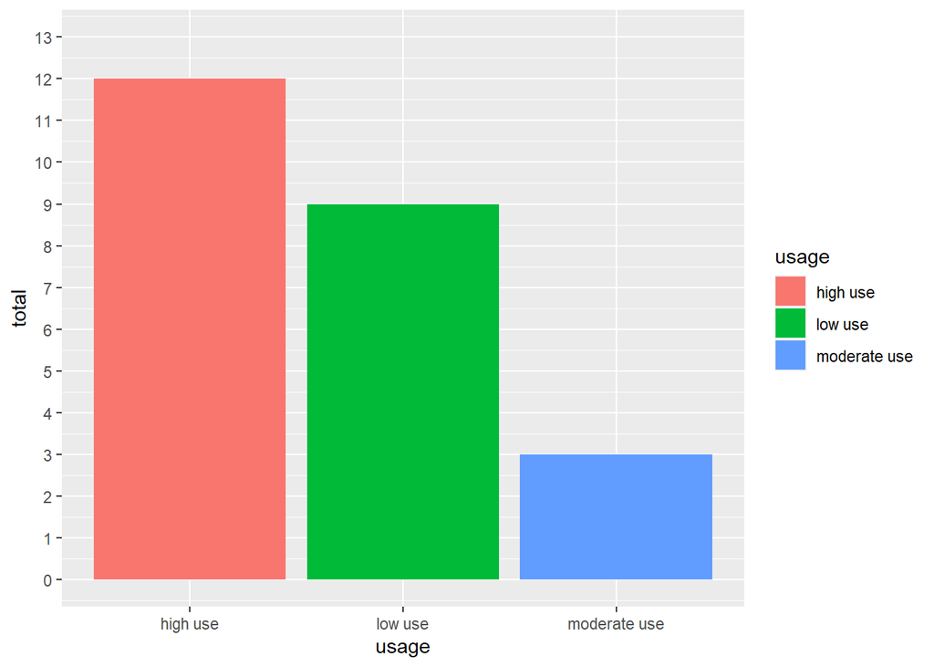

```r
activity %>%
    group_by(usage) %>%
    summarise(total = n_distinct(id)) %>%
    ggplot() +
      geom_col(mapping = aes(x = usage, y = total, fill = usage)) +
      scale_y_continuous(breaks = seq(0, 13, by = 1), limits = c(0, 13))
```

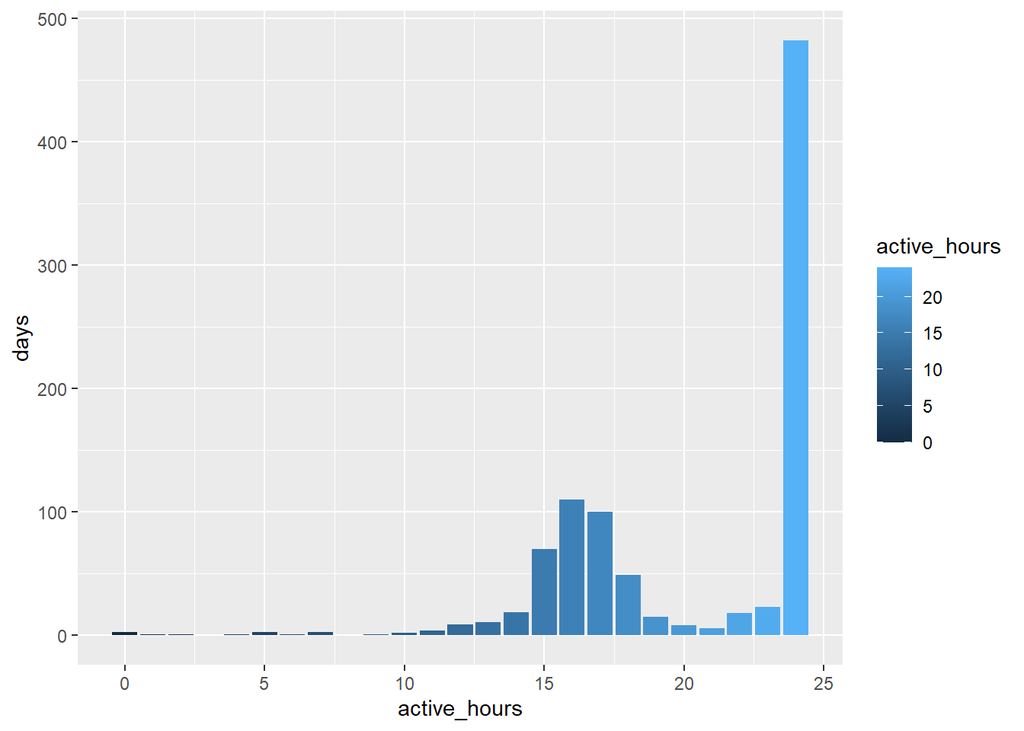

```r
daily_activity %>%
  mutate("active_minutes" = very_active_minutes +
    fairly_active_minutes + lightly_active_minutes + sedentary_minutes) %>%
  mutate("active_hours" = round(active_minutes / 60)) %>%
  group_by(active_hours) %>%
  summarise("days" = n()) %>%
  ggplot() +
    geom_col(mapping = aes(x = active_hours, y = days, fill = active_hours))
```

```r
activity_percent <- activity %>%
  group_by(usage) %>%
  summarise(total = n_distinct(id)) %>%
  mutate(totals = sum(total)) %>%
  group_by(usage) %>%
  summarise(total, total_percent = scales::percent(total / totals))

head(activity_percent)
```

```
## # A tibble: 3 x 3
##   usage        total total_percent
##   <chr>        <int> <chr>
## 1 high use        12 50%
## 2 low use          9 38%
## 3 moderate use     3 12%
```

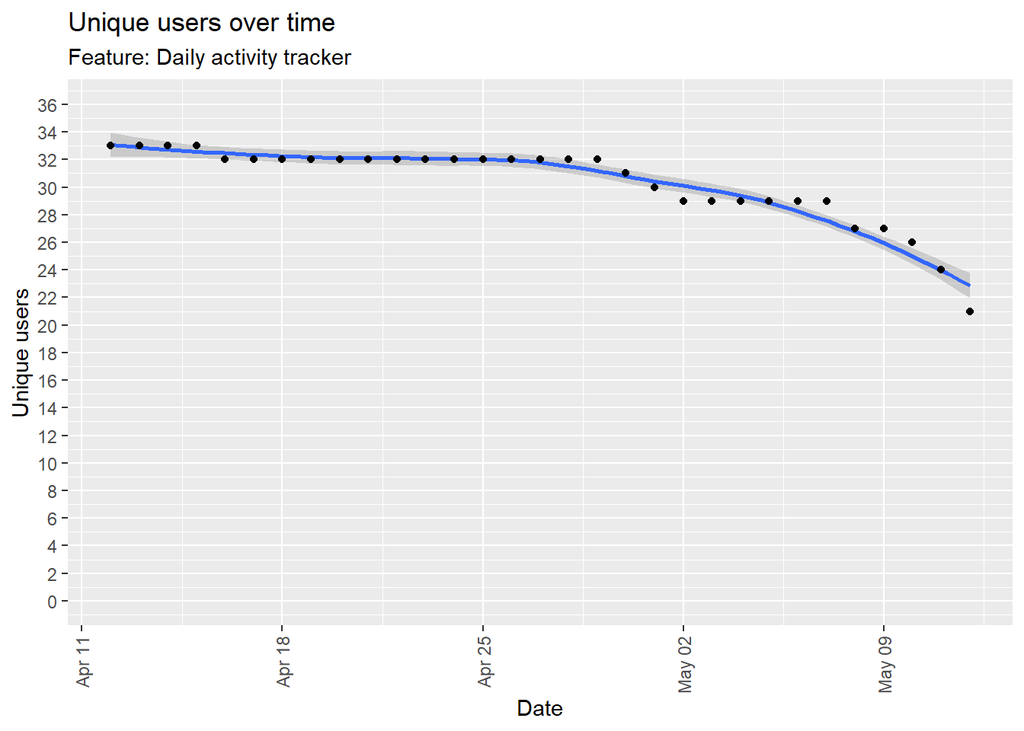

```r
daily_activity %>%
  group_by(date) %>%
  summarize("unique_users" = n_distinct(id)) %>%
  ggplot() +
    geom_smooth(mapping = aes(x = date, y = unique_users)) +
    geom_point(mapping = aes(x = date, y = unique_users)) +
    labs(title = "Unique users over time",
      subtitle = "Feature: Daily activity tracker",
      x = "Date",
      y = "Unique users") +
    scale_y_continuous(breaks = seq(0, 36, by = 2), limits = c(0, 36)) +
    theme(axis.text.x = element_text(angle = 90, vjust = 0.5, hjust = 1))
```

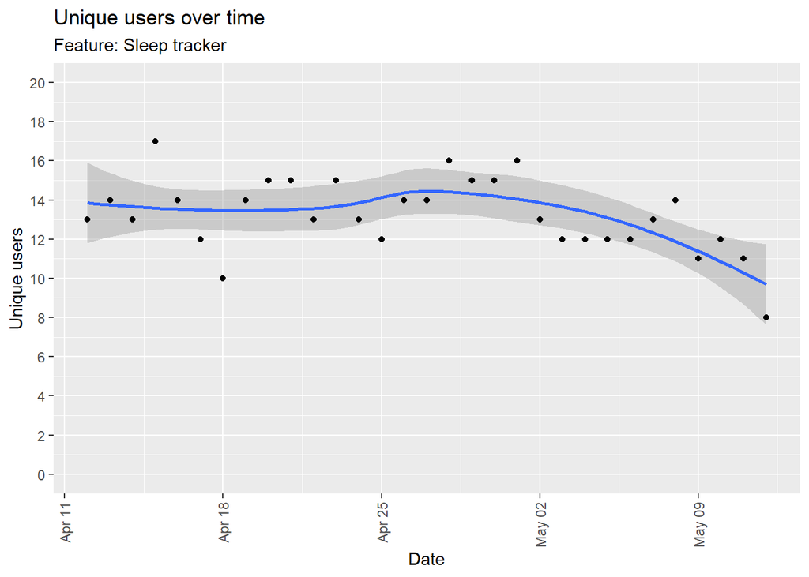

```r
sleep_day %>%
  group_by(date) %>%
  summarize("unique_users" = n_distinct(id)) %>%
  ggplot() +
    geom_smooth(mapping = aes(x = date, y = unique_users)) +
    geom_point(mapping = aes(x = date, y = unique_users)) +
    labs(title = "Unique users over time",
      subtitle = "Feature: Sleep tracker",
      x = "Date",
      y = "Unique users") +
    scale_y_continuous(breaks = seq(0, 20, by = 2), limits = c(0, 20)) +
    theme(axis.text.x = element_text(angle = 90, vjust = 0.5, hjust = 1))
```

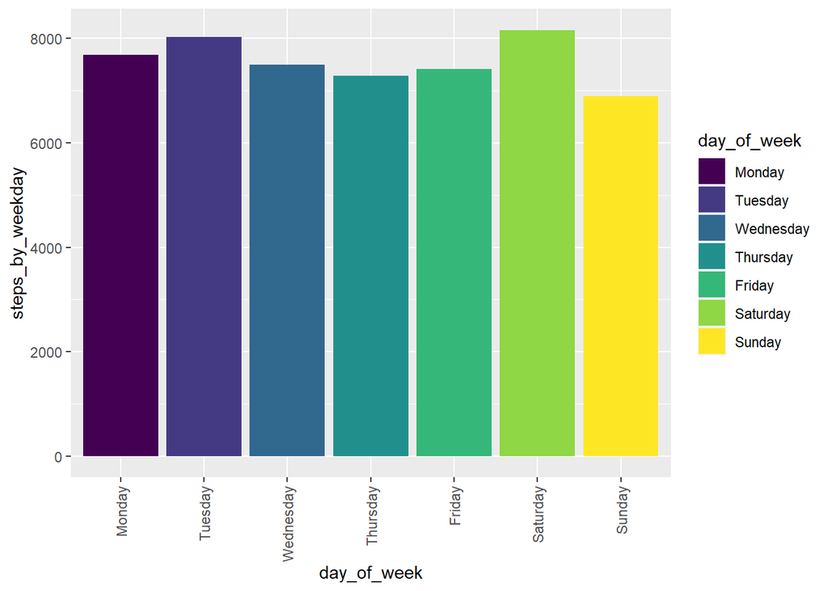

```r
daily_steps_avg <- hourly_steps %>%
  group_by(date, id, day_of_week) %>%
  summarise(steps_by_day = sum(step_total)) %>%
  group_by(day_of_week) %>%
  summarise(steps_by_weekday = mean(steps_by_day))


daily_steps_avg$day_of_week <- ordered(daily_steps_avg$day_of_week, levels =
c("Monday", "Tuesday", "Wednesday", "Thursday", "Friday", "Saturday", "Sunday"))

daily_steps_avg %>%
  ggplot() +
    geom_col(mapping = aes(x = day_of_week, y = steps_by_weekday, fill = day_of_week)) + # nolint
    theme(axis.text.x = element_text(angle = 90, vjust = 0.5, hjust = 1))
```

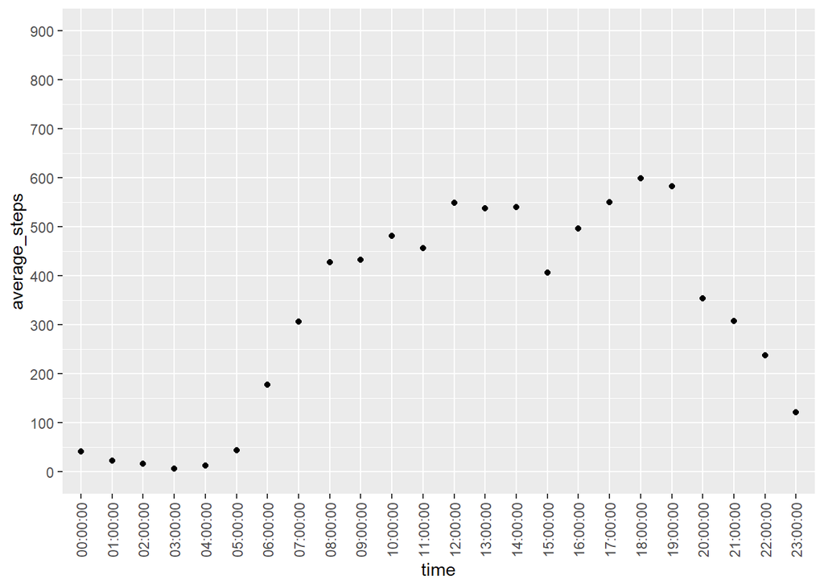

```r
hourly_steps %>%
  group_by(time) %>%
  summarise(average_steps = mean(step_total)) %>%
  ggplot() +
    geom_point(mapping = aes(x = time, y = average_steps)) +
    theme(axis.text.x = element_text(angle = 90, vjust = 0.5, hjust = 1)) +
    scale_y_continuous(breaks = seq(0, 900, by = 100), limits = c(0, 900))
```

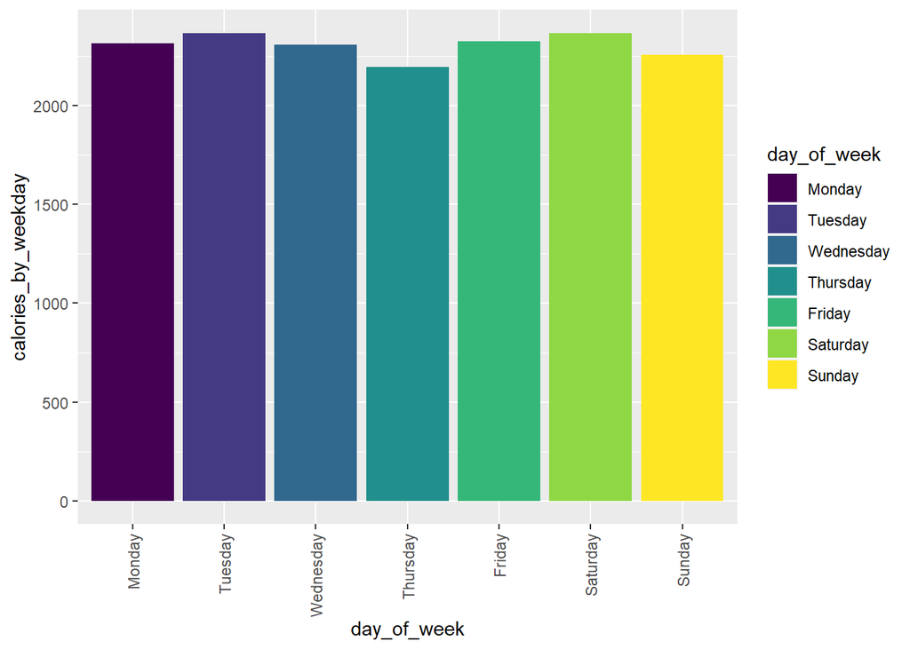

```r
daily_calories_avg <- hourly_calories %>%
  group_by(date, id, day_of_week) %>%
  summarise(calories_by_day = sum(calories)) %>%
  group_by(day_of_week) %>%
  summarise(calories_by_weekday = mean(calories_by_day))


daily_calories_avg$day_of_week <- ordered(daily_calories_avg$day_of_week, levels = # nolint
c("Monday", "Tuesday", "Wednesday", "Thursday", "Friday", "Saturday", "Sunday"))

daily_calories_avg %>%
  ggplot() +
    geom_col(mapping = aes(x = day_of_week, y = calories_by_weekday, fill = day_of_week)) + # nolint
    theme(axis.text.x = element_text(angle = 90, vjust = 0.5, hjust = 1))
```

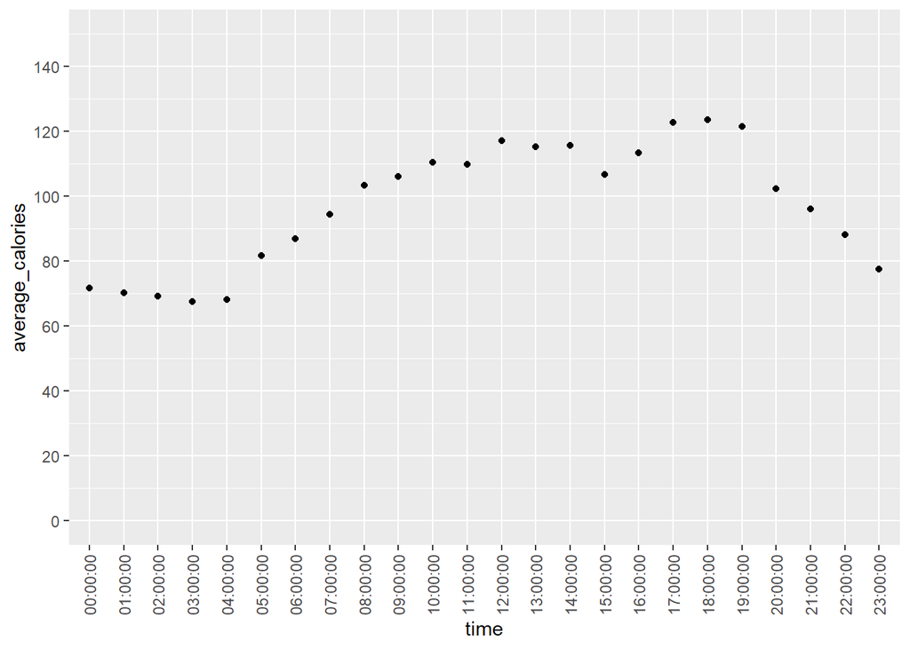

```r
hourly_calories %>%
  group_by(time) %>%
  summarise(average_calories = mean(calories)) %>%
  ggplot() +
    geom_point(mapping = aes(x = time, y = average_calories)) +
    theme(axis.text.x = element_text(angle = 90, vjust = 0.5, hjust = 1)) +
    scale_y_continuous(breaks = seq(0, 150, by = 20), limits = c(0, 150))
```

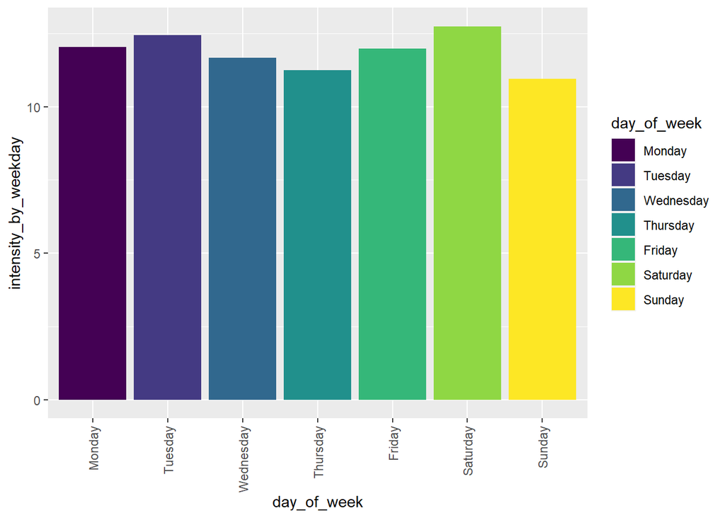

```r
daily_intensity_avg <- hourly_intensities %>%
  group_by(date, id, day_of_week) %>%
  summarise(intensity_by_day = sum(total_intensity) / 24) %>%
  group_by(day_of_week) %>%
  summarise(intensity_by_weekday = mean(intensity_by_day))


daily_intensity_avg$day_of_week <- ordered(daily_intensity_avg$day_of_week, levels = # nolint
c("Monday", "Tuesday", "Wednesday", "Thursday", "Friday", "Saturday", "Sunday"))

daily_intensity_avg %>%
  ggplot() +
    geom_col(mapping = aes(x = day_of_week, y = intensity_by_weekday, fill = day_of_week)) + # nolint
    theme(axis.text.x = element_text(angle = 90, vjust = 0.5, hjust = 1))
```

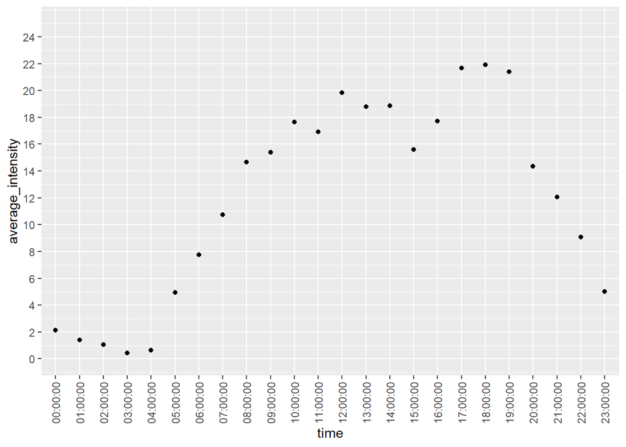

```r
hourly_intensities %>%
  group_by(time) %>%
  summarise(average_intensity = mean(total_intensity)) %>%
  ggplot() +
    geom_point(mapping = aes(x = time, y = average_intensity)) +
    theme(axis.text.x = element_text(angle = 90, vjust = 0.5, hjust = 1)) +
    scale_y_continuous(breaks = seq(0, 25, by = 2), limits = c(0, 25))
```